# Predict and cluster on ConsensusPathDB – Overlap Gene Shot with 10 publications – Saverunner results

Stephanie Hickey

6/15/2022

```r
knitr::opts_chunk$set(echo = TRUE)
library(tidyverse)
library(ROCR)
library(pheatmap)
library(RColorBrewer)
library(ggforce)
library(patchwork)
library(ggplotify)
library(fgsea)
source("./src/chronic_inflammation_functions.R")
```

## Drug repurposing results

From SaveRunner on ConsensusPathDB

#### Count significant (FDR < .01) drug-disease pairs

```r
# all drug results
drugs = read.delim("./drugs/Results/Drug_Disease_network.txt")

# change colnames and add new disease column
drugs =
  drugs %>%
  rename(Cluster = disease)

drugs$Disease = sub("_[^_]+$", "", drugs$Cluster)

# add TraitType
# get complex vs ai lables
c_v_ai = read.csv("./data/complex_ai.csv", header = F)

# change disease to match file names
c_v_ai$Disease = gsub(" ", "_", c_v_ai$V1)
c_v_ai$Disease = gsub("([_])|[[:punct:]]", "\\1", c_v_ai$Disease)
c_v_ai$Disease = gsub("_[^_]*$", "", c_v_ai$Disease)

ai =
  c_v_ai %>%
  filter(V2 == "autoimmune") %>%
  pull(Disease)

complex =
  c_v_ai %>%
  filter(V2 == "complex") %>%
  pull(Disease)

drugs =
  drugs %>%
  mutate(TraitType =
           case_when(Disease %in% ai ~ "Autoimmune Disease",
                     Disease %in% complex ~ "Complex Disease",
                     !Disease %in% c(ai,
                                     complex,
                                     "Adenocarcinoma_of_lung_disorder") ~ "Non-disease Trait",
                     Disease == "Adenocarcinoma_of_lung_disorder" ~ "Complex Disease"))

# add gene plexus cv to plot
# only include traits with at least 15 seed genes

load("./results/GenePlexus_parameter_checks/Geneplexus_summary_new_networks.Rdata")

cv_df =
  summary_df %>%
  filter(Network == "ConsensusPathDB") %>%
  select(Disease,
         nSeeds,
         CVscore)

# remove colitis, it's not an autoimmune disease or complex disease, really
drugs =
  drugs %>%
  left_join(cv_df) %>%
  filter(!Disease == "Colitis",
         nSeeds >= 15,
         CVscore >= 1)

# correct for multiple comparisons within disease
drugs =
  drugs %>%
  group_by(Disease) %>%
  mutate(FDR = p.adjust(pval, method = "BH"))

# Some drugs are associated with a disease through more
# than one cluster. Choose the drug-disease pair with the
# lowest FDR
drugs_collapse =
  drugs %>%
  group_by(drug,
           Disease) %>%
  slice(which.min(FDR))

# Calculate proportion of significant drug-disease pairs
# set FDR threshold
cutoff = .01

# tally all drug-disease pairs we found for ai's and complex disease
tally_drugs =
  drugs_collapse %>%
  filter(FDR <= cutoff,
         CVscore >= 1) %>%
  group_by(TraitType) %>%
  tally(name = "nDrugDiseasePair")

# tally diseases with significant drugs
tally_disease =
  drugs_collapse %>%
  ungroup() %>%
  filter(FDR <= cutoff,
         CVscore >= 1) %>%
  select(Disease, TraitType) %>%
  distinct() %>%
  group_by(TraitType) %>%
  tally(name = "nDisease")

tally_drugs_disease =
  left_join(tally_disease, tally_drugs)

knitr::kable(tally_drugs_disease)
```

| TraitType | nDisease | nDrugDiseasePair |
| --- | --- | --- |
| Autoimmune Disease | 9 | 1004 |
| Complex Disease | 18 | 1031 |

We found drugs for every autoimmune and complex disease with a CI overlapping cluster

```r
# tally all drug-disease pairs we found for each disease
tally_drugs_disease =
  drugs_collapse %>%
  filter(FDR <= cutoff,
         CVscore >= 1) %>%
  select(TraitType,
         Disease,
         drug) %>%
  distinct() %>%
  group_by(TraitType,
           Disease) %>%
  tally(name = "nDrugDiseasePair")

# filter for significant drug disease pairs
sig_drugs =
  drugs_collapse %>%
  filter(FDR < cutoff,
         CVscore >= 1)

knitr::kable(tally_drugs_disease %>% arrange(TraitType, desc(nDrugDiseasePair)))
```

| TraitType | Disease | nDrugDiseasePair |
| --- | --- | --- |
| Autoimmune Disease | Crohn_Disease | 186 |
| Autoimmune Disease | Diabetes_Mellitus_InsulinDependent | 157 |
| Autoimmune Disease | Ulcerative_Colitis | 129 |
| Autoimmune Disease | Psoriasis | 107 |
| Autoimmune Disease | Rheumatoid_Arthritis | 106 |
| Autoimmune Disease | Lupus_Erythematosus_Systemic | 99 |
| Autoimmune Disease | Behcet_Syndrome | 81 |
| Autoimmune Disease | Multiple_Sclerosis | 81 |
| Autoimmune Disease | Celiac_Disease | 58 |
| Complex Disease | Chronic_Obstructive_Airway_Disease | 182 |
| Complex Disease | Nonalcoholic_Fatty_Liver_Disease | 157 |
| Complex Disease | Atherosclerosis | 148 |
| Complex Disease | Myocardial_Ischemia | 98 |
| Complex Disease | Myocardial_Infarction | 90 |
| Complex Disease | Coronary_Arteriosclerosis | 62 |
| Complex Disease | Kidney_Failure_Chronic | 55 |
| Complex Disease | Malignant_mesothelioma | 51 |
| Complex Disease | Fatty_Liver | 49 |
| Complex Disease | Pulmonary_Emphysema | 43 |
| Complex Disease | Endometriosis | 25 |
| Complex Disease | Malignant_neoplasm_of_pancreas | 18 |
| Complex Disease | Malignant_neoplasm_of_kidney | 15 |
| Complex Disease | Alzheimers_Disease | 12 |
| Complex Disease | Malignant_tumor_of_colon | 12 |
| Complex Disease | Small_cell_carcinoma_of_lung | 7 |
| Complex Disease | Malignant_neoplasm_of_lung | 4 |
| Complex Disease | Squamous_cell_carcinoma_of_lung | 3 |

#### Check for previous drug/disease associations

**Match indications in Drug Central with disease concept id**

Use the disease concept id to exactly match diseases in our data to diseases/Neoplastic process in drug central. This is strict in that it if we associate a drug to “Psoriasis” and drug central has an indication for “Plaque Psoriasis” it will not be marked as previously indicated. However, this method is consistent across our diseases.

```r
# load IDs for our diseases
all_disease = read.csv("./data/chronic_inflammation_diseases_with_DOID.csv", row.names = 1)

# get rid of DOID and names
all_disease =
  all_disease %>%
  select(diseaseId,
         diseaseName) %>%
  distinct()

#change disease names to match ours
all_disease$diseaseName = gsub(" ", "_", all_disease$diseaseName)
all_disease$diseaseName = gsub("([_])|[[:punct:]]", "\\1", all_disease$diseaseName)

# filter for diseases with significant results
disease_sig  =
  all_disease %>%
  filter(diseaseName %in% unique(sig_drugs$Disease))

colnames(disease_sig) = c("umls_cui", "Disease")

# load drug central data from Alex
indications = read.delim("./drugs/data/drugcentral/indications.tsv")
# ids for drugs filtered through expert curation
struct_ids = read.delim("./drugs/data/drugcentral/structid_drugnames.tsv")

# filter indications by curated struct_ids
# and add the drug_names
indications = merge(indications,
                    struct_ids,
                    by = "struct_id")

# filter for indication or off-label use
# filter for diseases and syndromes T047 and Neoplastic process T191
# https://www.ncbi.nlm.nih.gov/pmc/articles/PMC4450611/
indications =
  indications %>%
  filter(relationship_name %in% c("indication","off-label use"),
         cui_semantic_type %in% c("T047", "T191"))

# add cuid for matching disease
sig_drugs =
  sig_drugs %>%
  left_join(disease_sig,
            by = "Disease")

# add struct_ids for matching drugs
struct_ids =
  struct_ids %>%
  rename(drug = drug_name)

sig_drugs =
  sig_drugs %>%
  left_join(struct_ids,
            by = "drug")

# add indications
indications_oi =
  indications %>%
  select(struct_id,
         umls_cui,
         relationship_name)

sig_drugs =
  sig_drugs %>%
  left_join(indications_oi,
            by = c("struct_id", "umls_cui")) %>%
  rename(Known_Relationship = relationship_name)

sig_drugs$Known_Relationship[is.na(sig_drugs$Known_Relationship)] = "none"

sig_drugs$Previously_indicated_umls_cui =
  ifelse(sig_drugs$Known_Relationship == "indication" |
           sig_drugs$Known_Relationship == "off-label use",
         TRUE,
         FALSE)

umls_match =
  sig_drugs %>%
  filter(Previously_indicated_umls_cui == TRUE) %>%
  group_by(Disease) %>%
  tally(name = "n previous drug associations")

knitr::kable(umls_match)
```

| Disease | n previous drug associations |
| --- | --- |
| Atherosclerosis | 1 |
| Celiac_Disease | 7 |
| Chronic_Obstructive_Airway_Disease | 7 |
| Crohn_Disease | 1 |
| Lupus_Erythematosus_Systemic | 1 |
| Myocardial_Infarction | 2 |
| Psoriasis | 2 |

Saverunner found previously indicated drugs for 4/9 autoimmune disease and 3/18 complex diseases.

#### Are our results enriched for drugs previously indicated to a disease?

```r
# find all diseases in drug central that match
# the diseases we have results for
# using the CU IDs

# fisher per disease
fisher_vec = {}
fisher_names = {}
ndrugs_DC_indicated_vec = {}
ndrugs_NOT_DC_indicated_vec = {}
ndrugs_ours_indicated_vec = {}
ndrugs_ours_NOT_indicated_vec = {}

all_drugs = unique(indications$drug_name)

for(d in disease_sig$umls_cui){

  drugs_DOI =
    indications %>%
    filter(umls_cui == d) %>%
    select(drug_name) %>%
    distinct() %>%
    pull

  ndrugs_DOI = length(drugs_DOI)
  ndrugs_NOT_DOI = length(all_drugs) - ndrugs_DOI

  for_fisher_our_results =
    sig_drugs %>%
    filter(umls_cui == d) %>%
    group_by(Previously_indicated_umls_cui) %>%
    tally() %>%
    pull(n)

  for_fisher = c(ndrugs_NOT_DOI, ndrugs_DOI, for_fisher_our_results)
  if(length(for_fisher)<4) {next}

   fish = fisher.test(matrix(for_fisher, 2, 2),
                alternative = "greater")$p.value

   fisher_names = c(fisher_names, d)
   fisher_vec = c(fisher_vec, fish)
   ndrugs_DC_indicated_vec = c(ndrugs_DC_indicated_vec, ndrugs_DOI)
   ndrugs_NOT_DC_indicated_vec = c(ndrugs_NOT_DC_indicated_vec, ndrugs_NOT_DOI)
   ndrugs_ours_indicated_vec = c(ndrugs_ours_indicated_vec, for_fisher_our_results[2])
   ndrugs_ours_NOT_indicated_vec = c(ndrugs_ours_NOT_indicated_vec, for_fisher_our_results[1])
}

fisher_res = data.frame(umls_cui = fisher_names,
                        nDrugs_indicated_Drug_Central = ndrugs_DC_indicated_vec,
                        nDrugs_associated_by_our_method = ndrugs_ours_indicated_vec +
                          ndrugs_ours_NOT_indicated_vec,
                        nDrugs_both = ndrugs_ours_indicated_vec,
                        pval = fisher_vec)

fisher_res = left_join(fisher_res, disease_sig)

fisher_res =
  fisher_res %>%
  arrange(pval)

fisher_res$FDR = p.adjust(fisher_res$pval, method = "BH")

knitr::kable(fisher_res %>% select(Disease, everything()))
```

| Disease | umls_cui | nDrugs_indicated_Drug_Central | nDrugs_associated_by_our_method | nDrugs_both | pval | FDR |
| --- | --- | --- | --- | --- | --- | --- |
| Celiac_Disease | C0007570 | 8 | 58 | 7 | 0.0000059 | 0.0000412 |
| Chronic_Obstructive_Airway_Disease | C0024117 | 15 | 182 | 7 | 0.0463095 | 0.1620832 |
| Myocardial_Infarction | C0027051 | 9 | 90 | 2 | 0.2396596 | 0.4342841 |
| Atherosclerosis | C0004153 | 1 | 148 | 1 | 0.2481623 | 0.4342841 |
| Psoriasis | C0033860 | 19 | 107 | 2 | 0.6363446 | 0.8908825 |
| Lupus_Erythematosus_Systemic | C0024141 | 16 | 99 | 1 | 0.8121022 | 0.9474526 |
| Crohn_Disease | C0010346 | 26 | 186 | 1 | 0.9918857 | 0.9918857 |

We did really well for `Celiac_Disease` but nothing else is significant. Where do the indicated drugs rank among the saverunner associated drugs?

```r
# add rank column
sig_drugs =
  sig_drugs %>%
  group_by(Disease) %>%
  arrange(FDR) %>%
  mutate(FDRrank = dense_rank(FDR))

check_rank =
  sig_drugs %>%
  filter(Previously_indicated_umls_cui == TRUE) %>%
  select(drug,
         Disease,
         TraitType,
         proximity,
         FDR,
         FDRrank)

to_add =
  fisher_res %>%
  select(Disease, nDrugs_associated_by_our_method)

knitr::kable(check_rank %>% left_join(to_add) %>% arrange(Disease, FDRrank))
```

| drug | Disease | TraitType | proximity | FDR | FDRrank | nDrugs_associated_by_our_method |
| --- | --- | --- | --- | --- | --- | --- |
| alirocumab | Atherosclerosis | Complex Disease | 1.0000000 | 0.0011968 | 52 | 148 |
| triamcinolone | Celiac_Disease | Autoimmune Disease | 1.0000000 | 0.0000007 | 4 | 58 |
| betamethasone | Celiac_Disease | Autoimmune Disease | 1.0000000 | 0.0011581 | 8 | 58 |
| triamcinolone diacetate | Celiac_Disease | Autoimmune Disease | 1.0000000 | 0.0011581 | 8 | 58 |
| cortisone acetate | Celiac_Disease | Autoimmune Disease | 1.0000000 | 0.0036459 | 9 | 58 |
| dexamethasone | Celiac_Disease | Autoimmune Disease | 1.0000000 | 0.0036459 | 9 | 58 |
| methylprednisolone | Celiac_Disease | Autoimmune Disease | 1.0000000 | 0.0081061 | 10 | 58 |
| prednisone | Celiac_Disease | Autoimmune Disease | 1.0000000 | 0.0081061 | 10 | 58 |
| betamethasone | Chronic_Obstructive_Airway_Disease | Complex Disease | 1.0000000 | 0.0000000 | 1 | 182 |
| cortisone acetate | Chronic_Obstructive_Airway_Disease | Complex Disease | 1.0000000 | 0.0000000 | 1 | 182 |
| methylprednisolone | Chronic_Obstructive_Airway_Disease | Complex Disease | 1.0000000 | 0.0000000 | 1 | 182 |
| prednisolone | Chronic_Obstructive_Airway_Disease | Complex Disease | 1.0000000 | 0.0000000 | 3 | 182 |
| triamcinolone | Chronic_Obstructive_Airway_Disease | Complex Disease | 1.0000000 | 0.0000000 | 3 | 182 |
| triamcinolone diacetate | Chronic_Obstructive_Airway_Disease | Complex Disease | 1.0000000 | 0.0000000 | 3 | 182 |
| prednisone | Chronic_Obstructive_Airway_Disease | Complex Disease | 1.0000000 | 0.0001864 | 28 | 182 |
| ustekinumab | Crohn_Disease | Autoimmune Disease | 0.6666667 | 0.0017471 | 77 | 186 |
| methotrexate | Lupus_Erythematosus_Systemic | Autoimmune Disease | 1.5000000 | 0.0018154 | 24 | 99 |
| atenolol | Myocardial_Infarction | Complex Disease | 1.0000000 | 0.0000003 | 6 | 90 |
| metoprolol | Myocardial_Infarction | Complex Disease | 1.0000000 | 0.0007944 | 22 | 90 |
| ustekinumab | Psoriasis | Autoimmune Disease | 0.6666667 | 0.0000002 | 12 | 107 |
| calcipotriene | Psoriasis | Autoimmune Disease | 1.0000000 | 0.0011371 | 36 | 107 |

#### auPRC with previously indictated drugs as positives

ranking stat is SAveRUNNER -log10(FDR)

```r
drugs_collapse$log10FDR = -log10(drugs_collapse$FDR)

# add struct_ids for matching drugs
drugs_collapse =
  drugs_collapse %>%
  left_join(struct_ids,
            by = "drug")

# add umls_cui for matching diseases
drugs_collapse =
  drugs_collapse %>%
  left_join(disease_sig,
            by = "Disease")

# add indications
drugs_collapse =
  drugs_collapse %>%
  left_join(indications_oi,
            by = c("struct_id", "umls_cui")) %>%
  rename(Known_Relationship = relationship_name)

drugs_collapse$Known_Relationship[is.na(drugs_collapse$Known_Relationship)] = "none"

drugs_collapse$Label =
  ifelse(drugs_collapse$Known_Relationship == "indication" |
           drugs_collapse$Known_Relationship == "off-label use",
         TRUE,
         FALSE)

auPRC_vec = {}
log2auRPC_vec = {}
disease_vec = {}
npos_vec = {}

check_disease =
  drugs_collapse %>%
  filter(CVscore >= 1) %>%
  pull(Disease) %>%
  unique()

for(d in check_disease){

  predictions =
    drugs_collapse %>%
    ungroup() %>%
    filter(Disease == d) %>%
    pull(log10FDR)

  labels =
    drugs_collapse %>%
    ungroup() %>%
    filter(Disease == d) %>%
    pull(Label)

  npos = sum(labels);

  if(npos >= 5){

  pred = prediction(predictions, labels)
  perf = performance(pred, "aucpr")

  auprc = perf@y.values[[1]]
  prior = npos/length(labels)
  log2AoP = log2(auprc/prior)

  auPRC_vec = c(auPRC_vec, auprc);
  log2auRPC_vec = c(log2auRPC_vec, log2AoP);
  disease_vec = c(disease_vec, d)
  npos_vec = c(npos_vec, npos)

  } else {next}

}

auPRC_res = data.frame(Disease = disease_vec,
                       auPRC = auPRC_vec,
                       log2auRPC = log2auRPC_vec,
                       npos = npos_vec
                       )

auPRC_res =
  auPRC_res %>%
  mutate(TraitType =
           case_when(Disease %in% ai ~ "Autoimmune Disease",
                     Disease %in% complex ~ "Complex Disease",
                     !Disease %in% c(ai, complex) ~ "Non-disease Trait"))

knitr::kable(auPRC_res %>% arrange(TraitType, desc(log2auRPC)))
```

| Disease | auPRC | log2auRPC | npos | TraitType |
| --- | --- | --- | --- | --- |
| Celiac_Disease | 0.1513993 | 4.5870431 | 8 | Autoimmune Disease |
| Multiple_Sclerosis | 0.0764739 | 2.5523762 | 17 | Autoimmune Disease |
| Ulcerative_Colitis | 0.0490561 | 2.2988636 | 13 | Autoimmune Disease |
| Psoriasis | 0.0529041 | 1.8592181 | 19 | Autoimmune Disease |
| Lupus_Erythematosus_Systemic | 0.0438677 | 1.8369252 | 16 | Autoimmune Disease |
| Crohn_Disease | 0.0421608 | 1.0803333 | 26 | Autoimmune Disease |
| Rheumatoid_Arthritis | 0.0429165 | 0.1339777 | 51 | Autoimmune Disease |
| Small_cell_carcinoma_of_lung | 0.0904292 | 4.2483219 | 6 | Complex Disease |
| Myocardial_Infarction | 0.0840253 | 3.7679295 | 8 | Complex Disease |
| Endometriosis | 0.0521560 | 2.4347851 | 12 | Complex Disease |
| Chronic_Obstructive_Airway_Disease | 0.0554316 | 2.2675830 | 15 | Complex Disease |
| Pulmonary_Emphysema | 0.0424091 | 1.8779214 | 15 | Complex Disease |

```r
auPRC_res_drug_central = auPRC_res
auPRC_res_drug_central$Source = "Drug Central"
```

### auPRC: positive drugs are in phavse IV clinincal trial for the disease

Ranking stat is SAveRUNNER -log10(FDR)

```r
# find disease mesh names
# using the disgenet disease mappings file
dis_ids = read.delim("/mnt/research/compbio/krishnanlab/data/disease-gene_annotations/disgenet/2020-10/disease_mappings.tsv")

msh_ids =
  dis_ids %>%
  filter(vocabulary == "MSH",
         diseaseId %in% disease_sig$umls_cui) %>%
  rename(umls_cui = diseaseId)

to_add =
  msh_ids %>%
  select(umls_cui,
         vocabularyName)

drugs_for_ct = left_join(drugs_collapse, to_add)

sig_drugs_for_ct =
  drugs_for_ct %>%
  filter(CVscore >= 1,
         FDR < cutoff)

# and check for disease/drug pairs in the
# clinical trial DB
# load ct

load("/mnt/research/compbio/krishnanlab/projects/chronic_inflammation/data/clinical_trials/20211004/basic_clinical_trial_info.rdata")

status_oi = c("Active, not recruiting",
              "Enrolling by invitation",
              "Recruiting",
              "Completed")

ct_pairs =
  ct %>%
  mutate(drug = tolower(intervention_mesh_term)) %>%
  filter(overall_status %in% status_oi,
         !is.na(drug),
         phase == "Phase 4") %>%
  select(condition_mesh_term,
         drug,
         nct_id) %>%
  rename(vocabularyName = condition_mesh_term)

ct_pairs$PairInCT = TRUE

# which of our pairs are in ct pairs?
# match by vocabularyName (mesh name)
# more than one mesh name per cui_id
# select for distinct cui_ids

our_pairs_in_ct =
  left_join(drugs_for_ct,
            ct_pairs,
            by = c("vocabularyName", "drug"))

# split by true and false
# collapse by cui_ids

true_pairs =
  our_pairs_in_ct %>%
  filter(PairInCT == TRUE) %>%
  select(-PairInCT, -vocabularyName, -nct_id) %>%
  distinct()

true_pairs$PairInCT = TRUE

remove_from_false =
  true_pairs %>%
  select(umls_cui, drug)

remove_from_false$Remove = TRUE

false_pairs =
  our_pairs_in_ct %>%
  filter(is.na(PairInCT)) %>%
  select(-PairInCT, -vocabularyName) %>%
  distinct() %>%
  left_join(remove_from_false) %>%
  filter(is.na(Remove)) %>%
  select(-Remove)

false_pairs$PairInCT = FALSE

final_pairs =
  rbind(true_pairs, false_pairs)

auPRC_vec = {}
log2auRPC_vec = {}
disease_vec = {}
npos_vec = {}

check_disease =
  final_pairs %>%
  filter(CVscore >= 1) %>%
  pull(Disease) %>%
  unique()

for(d in check_disease){

  predictions =
    final_pairs %>%
    ungroup() %>%
    filter(Disease == d) %>%
    pull(log10FDR)

  labels =
    final_pairs %>%
    ungroup() %>%
    filter(Disease == d) %>%
    pull(PairInCT)

  npos = sum(labels);

  if(npos >= 5){

  pred = prediction(predictions, labels)
  perf = performance(pred, "aucpr")

  auprc = perf@y.values[[1]]
  prior = npos/length(labels)
  log2AoP = log2(auprc/prior)

  auPRC_vec = c(auPRC_vec, auprc);
  log2auRPC_vec = c(log2auRPC_vec, log2AoP);
  disease_vec = c(disease_vec, d)
  npos_vec = c(npos_vec, npos)

  } else {next}

}

auPRC_res = data.frame(Disease = disease_vec,
                       auPRC = auPRC_vec,
                       log2auRPC = log2auRPC_vec,
                       npos = npos_vec
                       )
auPRC_res =
  auPRC_res %>%
  mutate(TraitType =
           case_when(Disease %in% ai ~ "Autoimmune Disease",
                     Disease %in% complex ~ "Complex Disease",
                     !Disease %in% c(ai, complex) ~ "Non-disease Trait"))

write.csv(auPRC_res, "./results/prediction_clusters_same_graph/chronic_inflammation_gene_shot_pubs_greater10--predictedWith--ConsensusPathDB--clusteredOn--ConsensusPathDB_phase4_clinical_trial_auPRC.csv")


knitr::kable(auPRC_res %>% arrange(desc(log2auRPC)))
```

| Disease | auPRC | log2auRPC | npos | TraitType |
| --- | --- | --- | --- | --- |
| Malignant_neoplasm_of_pancreas | 0.0980721 | 3.8254668 | 9 | Complex Disease |
| Endometriosis | 0.0686790 | 3.4167827 | 8 | Complex Disease |
| Ulcerative_Colitis | 0.1156163 | 3.3292540 | 15 | Autoimmune Disease |
| Malignant_tumor_of_colon | 0.0565693 | 2.8606639 | 10 | Complex Disease |
| Malignant_neoplasm_of_kidney | 0.0561613 | 2.8309929 | 10 | Complex Disease |
| Lupus_Erythematosus_Systemic | 0.0532973 | 2.6583958 | 11 | Autoimmune Disease |
| Crohn_Disease | 0.0465301 | 2.0161460 | 15 | Autoimmune Disease |
| Nonalcoholic_Fatty_Liver_Disease | 0.0431244 | 2.0060214 | 14 | Complex Disease |
| Malignant_neoplasm_of_lung | 0.0794092 | 1.7901086 | 29 | Complex Disease |
| Fatty_Liver | 0.0453300 | 1.6987212 | 18 | Complex Disease |
| Psoriasis | 0.0516329 | 1.4281994 | 25 | Autoimmune Disease |
| Alzheimers_Disease | 0.0414806 | 1.2248684 | 23 | Complex Disease |
| Multiple_Sclerosis | 0.0548174 | 1.1151124 | 33 | Autoimmune Disease |
| Kidney_Failure_Chronic | 0.0685840 | 1.1062607 | 41 | Complex Disease |
| Diabetes_Mellitus_InsulinDependent | 0.0364311 | 0.9261855 | 25 | Autoimmune Disease |
| Myocardial_Infarction | 0.0628235 | 0.7938224 | 47 | Complex Disease |
| Chronic_Obstructive_Airway_Disease | 0.0385696 | 0.6970345 | 31 | Complex Disease |
| Atherosclerosis | 0.0429595 | 0.5599204 | 38 | Complex Disease |
| Rheumatoid_Arthritis | 0.0417057 | 0.3727994 | 42 | Autoimmune Disease |
| Coronary_Arteriosclerosis | 0.0749957 | 0.0267169 | 96 | Complex Disease |
| Myocardial_Ischemia | 0.0469633 | -0.1721178 | 69 | Complex Disease |

## Table S9: SAveRUNNER results

Add info from the pvalue filtered SAveRUNNER results because these include the `adjusted_similarity` measure that we can sort by.

```r
drugs05 = read.delim("/mnt/research/compbio/krishnanlab/projects/chronic_inflammation/drugs/Results/network/txtFile/Drug_Disease_network_pval0.05.txt")

drugs05 =
  drugs05 %>%
  rename(Cluster = disease) %>%
  select(-pval,
         -proximity)

drugs05$Disease = sub("_[^_]+$", "", drugs05$Cluster)

final_pairs_sim =
  left_join(final_pairs, drugs05)
S9 =
  final_pairs_sim %>%
  select(Disease,
         TraitType,
         Cluster,
         drug,
         pval,
         FDR,
         Known_Relationship,
         PairInCT,
         adjusted_similarity)

figure_path = "./results/prediction_clusters_same_graph/figures"
write.csv(S9, file = paste0(figure_path, "/TableS9_SAveRUNNER_results.csv"), row.names = F)
```

### Top for autoimmune diseases

```r
ai_res =
  final_pairs_sim %>%
  filter(TraitType == "Autoimmune Disease",
         FDR <= cutoff) %>%
  group_by(Disease) %>%
  top_n(5, adjusted_similarity) %>%
  top_n(-1, FDR) %>%
  select(Disease,
         TraitType,
         drug,
         proximity,
         FDR,
         adjusted_similarity,
         Known_Relationship,
         PairInCT) %>%
  distinct() %>%
  arrange(Disease, FDR, desc(adjusted_similarity))
knitr::kable(ai_res)
```

| Disease | TraitType | drug | proximity | FDR | adjusted_similarity | Known_Relationship | PairInCT |
| --- | --- | --- | --- | --- | --- | --- | --- |
| Behcet_Syndrome | Autoimmune Disease | pimavanserin | 1.0000000 | 0e+00 | 0.9738289 | none | FALSE |
| Behcet_Syndrome | Autoimmune Disease | romiplostim | 1.0000000 | 0e+00 | 0.9738289 | none | FALSE |
| Celiac_Disease | Autoimmune Disease | pioglitazone | 1.0000000 | 0e+00 | 0.9727707 | none | FALSE |
| Crohn_Disease | Autoimmune Disease | azatadine | 1.0000000 | 0e+00 | 0.9870763 | none | FALSE |
| Crohn_Disease | Autoimmune Disease | bepotastine | 1.0000000 | 0e+00 | 0.9870763 | none | FALSE |
| Crohn_Disease | Autoimmune Disease | mepyramine | 1.0000000 | 0e+00 | 0.9870763 | none | FALSE |
| Diabetes_Mellitus_InsulinDependent | Autoimmune Disease | dimenhydrinate | 1.0000000 | 0e+00 | 0.9870763 | none | FALSE |
| Lupus_Erythematosus_Systemic | Autoimmune Disease | epoetin beta | 1.0000000 | 0e+00 | 0.9870763 | none | FALSE |
| Lupus_Erythematosus_Systemic | Autoimmune Disease | peginesatide | 1.0000000 | 0e+00 | 0.9870763 | none | FALSE |
| Multiple_Sclerosis | Autoimmune Disease | bremelanotide | 1.0000000 | 1e-07 | 0.9870763 | none | FALSE |
| Psoriasis | Autoimmune Disease | fexofenadine | 1.0000000 | 0e+00 | 0.9870763 | none | FALSE |
| Psoriasis | Autoimmune Disease | mepyramine | 1.0000000 | 0e+00 | 0.9870763 | none | FALSE |
| Rheumatoid_Arthritis | Autoimmune Disease | muromonab-cd3 | 0.3333333 | 0e+00 | 0.9982515 | none | FALSE |
| Ulcerative_Colitis | Autoimmune Disease | eltrombopag | 1.0000000 | 0e+00 | 0.9738289 | none | FALSE |
| Ulcerative_Colitis | Autoimmune Disease | romosozumab | 1.0000000 | 0e+00 | 0.9738289 | none | FALSE |

### Top For complex diseases

```r
complex_res =
  final_pairs_sim %>%
  filter(TraitType == "Complex Disease",
         FDR <= cutoff) %>%
  group_by(Disease) %>%
  top_n(5, adjusted_similarity) %>%
  top_n(-1, FDR) %>%
  select(Disease,
         TraitType,
         drug,
         proximity,
         FDR,
         adjusted_similarity,
         Known_Relationship,
         PairInCT) %>%
  distinct() %>%
  arrange(Disease, FDR, desc(adjusted_similarity))

knitr::kable(complex_res)
```

| Disease | TraitType | drug | proximity | FDR | adjusted_similarity | Known_Relationship | PairInCT |
| --- | --- | --- | --- | --- | --- | --- | --- |
| Alzheimers_Disease | Complex Disease | apatinib | 1 | 0 | 0.2366069 | none | FALSE |
| Atherosclerosis | Complex Disease | brompheniramine | 0 | 0 | 0.9998286 | none | FALSE |
| Chronic_Obstructive_Airway_Disease | Complex Disease | clemastine | 1 | 0 | 0.9870763 | none | FALSE |
| Chronic_Obstructive_Airway_Disease | Complex Disease | hydroxyzine | 1 | 0 | 0.9870763 | none | FALSE |
| Coronary_Arteriosclerosis | Complex Disease | testosterone undecanoate | 1 | 0 | 0.9870763 | none | FALSE |
| Endometriosis | Complex Disease | maraviroc | 1 | 0 | 0.9727707 | none | FALSE |
| Endometriosis | Complex Disease | methylprednisolone | 1 | 0 | 0.9727707 | none | FALSE |
| Fatty_Liver | Complex Disease | filgrastim | 1 | 0 | 0.9870763 | none | FALSE |
| Kidney_Failure_Chronic | Complex Disease | peginesatide | 1 | 0 | 0.9870763 | none | FALSE |
| Malignant_mesothelioma | Complex Disease | bepotastine | 1 | 0 | 0.9870763 | none | FALSE |
| Malignant_mesothelioma | Complex Disease | desloratadine | 1 | 0 | 0.9870763 | none | FALSE |
| Malignant_mesothelioma | Complex Disease | triprolidine | 1 | 0 | 0.9870763 | none | FALSE |
| Malignant_neoplasm_of_kidney | Complex Disease | vardenafil | 1 | 0 | 0.9738289 | none | FALSE |
| Malignant_neoplasm_of_lung | Complex Disease | plerixafor | 1 | 0 | 0.9727707 | none | FALSE |
| Malignant_neoplasm_of_pancreas | Complex Disease | lanreotide | 1 | 0 | 0.7116316 | none | FALSE |
| Malignant_tumor_of_colon | Complex Disease | gemtuzumab ozogamicin | 1 | 0 | 0.9727707 | none | FALSE |
| Malignant_tumor_of_colon | Complex Disease | maraviroc | 1 | 0 | 0.9727707 | none | FALSE |
| Myocardial_Infarction | Complex Disease | epoetin alfa | 1 | 0 | 0.9870763 | none | TRUE |
| Myocardial_Infarction | Complex Disease | diphenhydramine | 1 | 0 | 0.9870763 | none | FALSE |
| Myocardial_Infarction | Complex Disease | olopatadine | 1 | 0 | 0.9870763 | none | FALSE |
| Myocardial_Ischemia | Complex Disease | clemastine | 1 | 0 | 0.9870763 | none | FALSE |
| Nonalcoholic_Fatty_Liver_Disease | Complex Disease | chenodiol | 0 | 0 | 0.9995530 | none | FALSE |
| Pulmonary_Emphysema | Complex Disease | apixaban | 1 | 0 | 0.9870763 | none | FALSE |
| Small_cell_carcinoma_of_lung | Complex Disease | vardenafil | 1 | 0 | 0.9738289 | none | FALSE |
| Squamous_cell_carcinoma_of_lung | Complex Disease | abiraterone acetate | 1 | 0 | 0.9738289 | none | FALSE |

## Figure 4

### Figure 4a: auPRC plots

Bind with Drug Central auPRC and plot

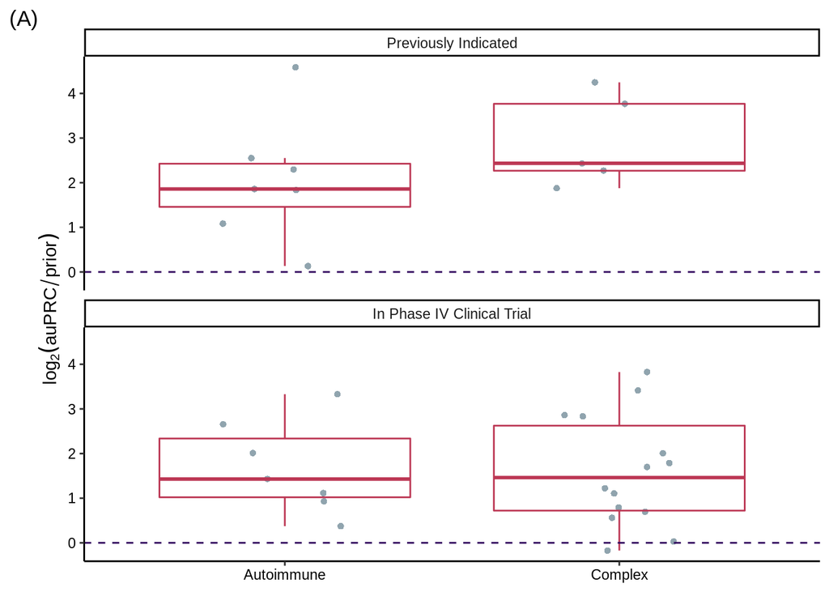

```r
auPRC_res$Source = "In Phase IV Clinical Trial"
auPRC_res = rbind(auPRC_res, auPRC_res_drug_central)

auPRC_res$Source = gsub("Drug Central",
                        "Previously Indicated",
                        auPRC_res$Source)

auPRC_res$Source = factor(auPRC_res$Source,
                          levels = c("Previously Indicated",
                                     "In Phase IV Clinical Trial"))

auPRC_res$TraitType = gsub(" Disease", "", auPRC_res$TraitType)

Fig4a =
  auPRC_res %>%
  ggplot(aes(x = TraitType,
             y = log2auRPC)) +
  geom_jitter(shape=16,
              colour = "#90A4AE",
              position=position_jitter(0.2)) +
  geom_boxplot(color = c("#bc3754"),
               fill = "NA",
               outlier.size=0,
               outlier.shape=NA) +
  geom_hline(yintercept=0,
             linetype="dashed",
             color = "#320a5e") +
  theme_classic() +
  #theme(axis.text.x = element_text(angle = 45,
                                   #hjust=1)) +
  theme(axis.title.x=element_blank()) +
  theme(axis.text.x=element_text(colour="black")) +
  theme(axis.text.y=element_text(colour="black")) +
  ylab(bquote(log[2](auPRC/prior))) +
  labs(tag = '(A)') +
  facet_wrap(~Source, ncol = 1)

ggsave(Fig4a, file = "/mnt/research/compbio/krishnanlab/projects/chronic_inflammation/results/prediction_clusters_same_graph/fig4a_check.png", width = 7.2, height = 7, dpi = 300, units = "in", device='png')

Fig4a
```

### Figure 4b

Stacked bar of number of drugs per disease + indicated + clical trial

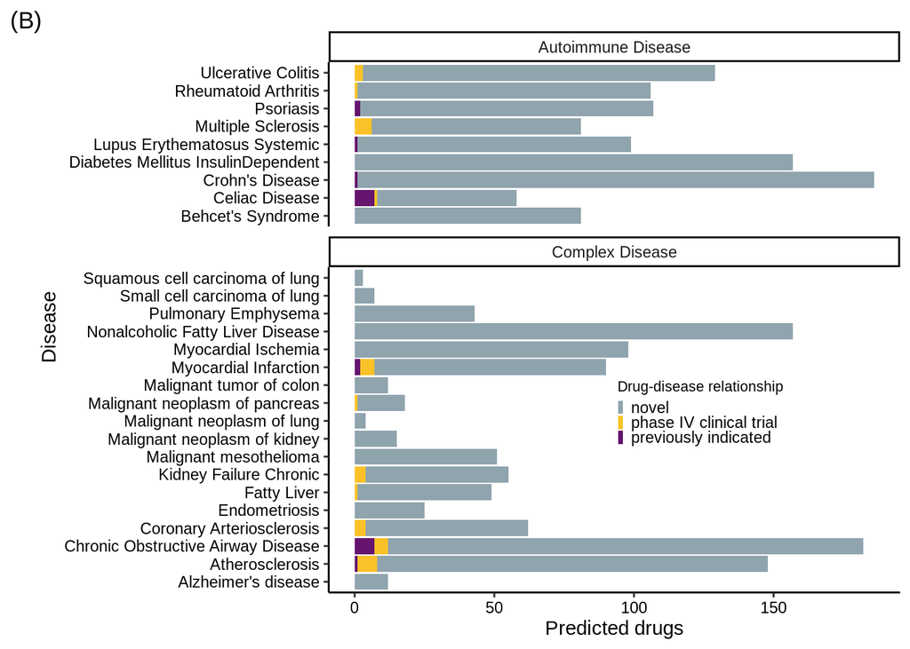

```r
final_pairs =
  final_pairs %>%
  mutate(plot_relationship =
           case_when(Known_Relationship == "indication" ~ "previously indicated",
                     Known_Relationship == "off-label use" ~ "previously indicated",
                     PairInCT == TRUE ~ "phase IV clinical trial",
                     PairInCT == FALSE & Known_Relationship == "none" ~ "novel"))

final_pairs$DiseaseNiceNames = gsub("_", " ", final_pairs$Disease)
final_pairs$DiseaseNiceNames = gsub("Alzheimers Disease", "Alzheimer's disease", final_pairs$DiseaseNiceNames)
final_pairs$DiseaseNiceNames = gsub("Behcet", "Behcet's", final_pairs$DiseaseNiceNames)
final_pairs$DiseaseNiceNames = gsub("Crohn", "Crohn's", final_pairs$DiseaseNiceNames)

final_pairs$plot_relationship = factor(final_pairs$plot_relationship,
                                   levels = c("novel",
                                              "phase IV clinical trial",
                                              "previously indicated"))
Fig4b =
final_pairs %>%
  filter(FDR < .01,
         TraitType != "Non-disease Trait") %>%
  group_by(DiseaseNiceNames,
           TraitType,
           plot_relationship) %>%
  tally(name="nDrugs") %>%
  ggplot(aes(x = DiseaseNiceNames,
             y = nDrugs,
             fill = plot_relationship)) +
  geom_bar(stat="identity") +
  #geom_text(aes(label = nDrugs),
            #position = position_stack(vjust = 0.5)) +
  scale_fill_manual(values=c("#90a4ae",
                             "#fac228",
                             "#65156e")) +
  xlab("Disease") +
  ylab("Predicted drugs") +
  guides(fill = guide_legend("Drug-disease relationship")) +
  labs(tag = '(B)') +
  theme_classic() +
  theme(legend.position = c(0.65, 0.34)) +
  theme(legend.title=element_text(size=8)) +
  theme(legend.key.size = unit(.05, 'in')) +
  theme(axis.text.x=element_text(colour="black")) +
  theme(axis.text.y=element_text(colour="black")) +
  coord_flip() +
  ggforce::facet_col(vars(TraitType), scales = "free_y", space = "free")

ggsave(Fig4b, file = "/mnt/research/compbio/krishnanlab/projects/chronic_inflammation/results/prediction_clusters_same_graph/fig4b_check.png", width = 7)

Fig4b
```

### Figure 4c: Antihistamine heatmap

Different antihistamines for different disorders? Use [atc codes](https://go.drugbank.com/atc/L04A) to ID antihistamines: R06

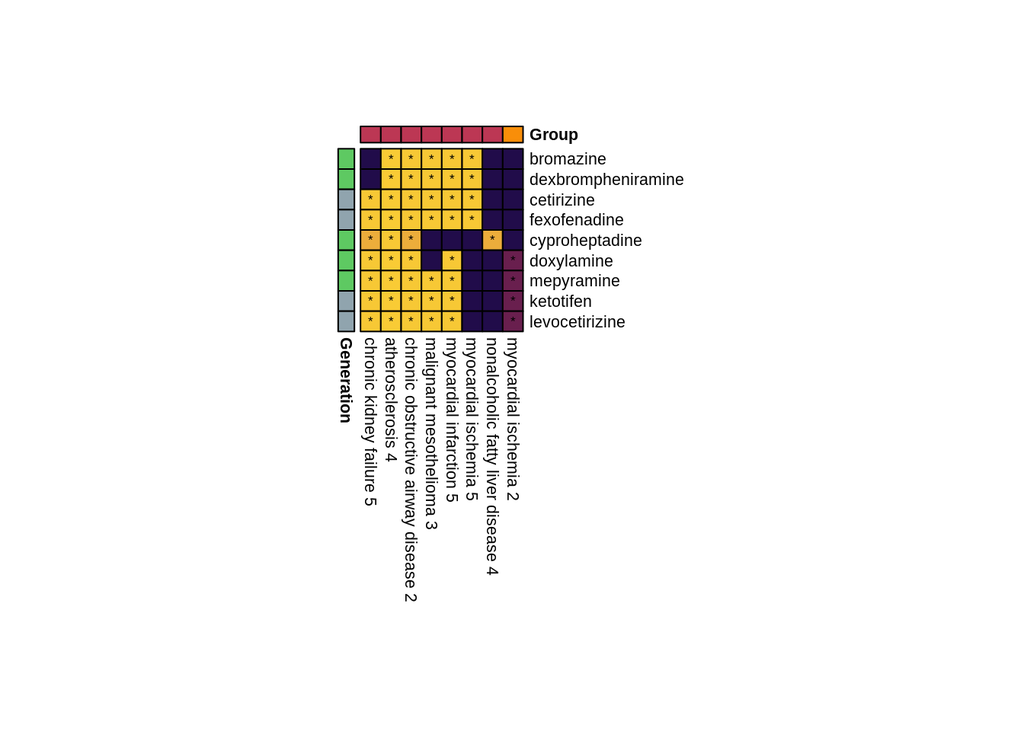

```r
# ATC code for drug target pairs are already in
# drug-target.tsv
drug_target = read.delim("/mnt/research/compbio/krishnanlab/projects/chronic_inflammation/drugs/data/drugcentral/drug-target.tsv")

# remove drug target info
# separate rows by atc code
# add column for whether or not
# the atc is AntiImmune
# grep for these at the beginning of
# a string

antihist =
  drug_target %>%
  select(-symbol,
         -entrez) %>%
  distinct() %>%
  separate_rows(atc, sep = ", ") %>%
  filter(grepl("^R06", atc)) %>%
  pull(drug_name) %>%
  unique()

## matrix of log10FDR
## these guys are variable across some diseases
antihist_FDR =
  final_pairs_sim %>%
  filter(drug %in% c("doxylamine",
                     "mepyramine",
                     "ketotifen",
                     "levocetirizine",
                     "bromazine",
                     "dexbrompheniramine",
                     "cyproheptadine",
                     "fexofenadine",
                     "cetirizine"),
         FDR < cutoff,
         TraitType == "Complex Disease") %>%
  mutate(log10FDR = -log10(FDR)) %>%
  select(Cluster, drug, log10FDR) %>%
  pivot_wider(id_cols = Cluster,
              names_from = drug,
              values_from = log10FDR,
              values_fill = 0)

antihist_FDR = as.data.frame(antihist_FDR)
rownames(antihist_FDR) = antihist_FDR$Cluster
antihist_FDR$Cluster = NULL

antihist_FDR_mat = do.call(data.frame,
                      lapply(antihist_FDR,
                             function(x) replace(x, is.infinite(x), 100)))

rownames(antihist_FDR_mat) = tolower(rownames(antihist_FDR_mat))

stars = antihist_FDR_mat
stars[stars < -log10(.01)] = ""
stars[stars != ""] = "*"

## matrix of adjusted similarity
antihist_sim =
  final_pairs_sim %>%
  filter(drug %in% c("doxylamine",
                     "mepyramine",
                     "ketotifen",
                     "levocetirizine",
                     "bromazine",
                     "dexbrompheniramine",
                     "cyproheptadine",
                     "fexofenadine",
                     "cetirizine"),
         FDR < cutoff,
         TraitType == "Complex Disease") %>%
  mutate(log10FDR = -log10(FDR)) %>%
  ungroup() %>%
  select(Cluster, drug, adjusted_similarity) %>%
  pivot_wider(id_cols = Cluster,
              names_from = drug,
              values_from = adjusted_similarity,
              values_fill = 0)

antihist_sim = as.data.frame(antihist_sim)
rownames(antihist_sim) = tolower(antihist_sim$Cluster)

antihist_sim$Cluster = NULL
antihist_sim_mat = as.matrix(antihist_sim)

# load group assignments for annotation

groups = read.csv("/mnt/research/compbio/krishnanlab/projects/chronic_inflammation/results/prediction_clusters_same_graph/subcluster_groups.csv", row.names = 1)

col_anno =
  groups %>%
  filter(DiseaseClusterNode %in% tolower(rownames(antihist_sim_mat))) %>%
  select(DiseaseClusterNode, Cluster) %>%
  rename(Group = Cluster) %>%
  as.data.frame()

rownames(col_anno) = col_anno$DiseaseClusterNode
col_anno$DiseaseClusterNode = NULL

hist_oi = c("doxylamine",
            "mepyramine",
            "ketotifen",
            "levocetirizine",
            "bromazine",
            "dexbrompheniramine",
            "cyproheptadine",
            "fexofenadine",
            "cetirizine")

gen = c("first",
        "first",
        "second",
        "second",
        "first",
        "first",
        "first",
        "second",
        "second")

row_anno = as.data.frame(gen)
colnames(row_anno) = "Generation"
rownames(row_anno) = hist_oi

## adj similarity heatmap
paletteLength <- 100
myColor = colorRampPalette(rev(c("#f9cb35", "#bc3754", "#210c4a")))((100))
pretty_names = gsub("_", " ", rownames(antihist_sim_mat))
pretty_names = gsub("kidney failure chronic", "chronic kidney failure", pretty_names)

ann_colors = list(
    Group = c(Group1 = "#f98e09",
              Group2 = "#bc3754"),
    Generation = c(first = "#5ec962",
                   second = "#90A4AE")
)


pheat =
  as.ggplot(
  pheatmap(t(antihist_sim_mat),
           color = myColor,
           border_color = "black",
           cluster_rows = TRUE,
           cluster_cols = TRUE,
           show_colnames = TRUE,
           show_rownames = TRUE,
           display_numbers = t(stars),
           treeheight_row = 0,
           treeheight_col = 0,
           number_color = "black",
           cellwidth = 10,
           cellheight = 10,
           legend = FALSE,
           labels_col = pretty_names,
           annotation_col = col_anno,
           annotation_row = row_anno,
           annotation_colors = ann_colors,
           annotation_legend = FALSE,
           width = 1.8,
           height = 1.8,
           fontsize = 8)) +
  labs(tag = "(C)") +
  theme(text = element_text(size = 10))
```

```r
ggsave(pheat, file = "./results/prediction_clusters_same_graph/drug_legend.png")
```

Composite

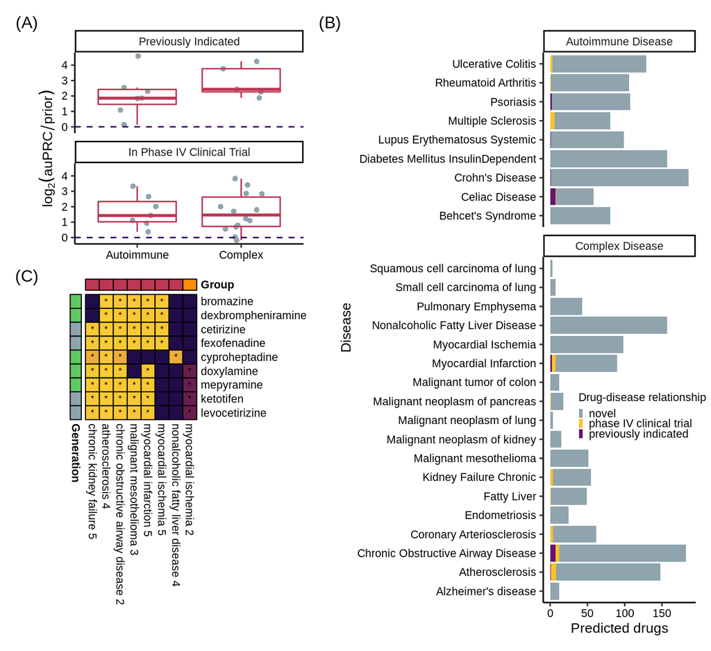

```r
Fig4b = Fig4b + theme(text = element_text(size = 10))
Fig4a = Fig4a + theme(text = element_text(size = 10))

Fig4 = ((Fig4a / pheat + plot_layout(heights = c(3,5))) | Fig4b) + plot_layout(widths = c(3,2))
ggsave(Fig4, file = "./results/prediction_clusters_same_graph/Fig4.png", width = 180, height = 165, units = "mm")

Fig4
```